# E. coli lineages under antibiotic exposure

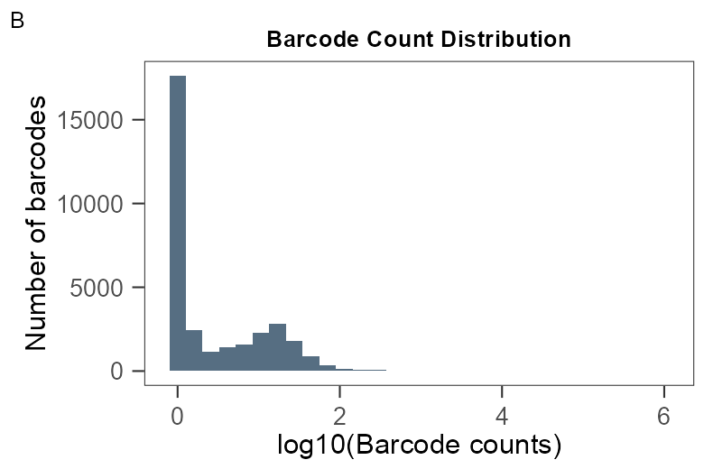

Panel B: barcode abundance, B1_p30

D · Length summary

| Length group | Sequences | Reads | Of sequences | Of reads |
| --- | --- | --- | --- | --- |
| 14 - 16 bp | 32,653 | 2,929,973 | 99.6% | 100.0% |
| < 14 bp | 122 | 460 | 0.4% | 0.0% |
| > 16 bp | 21 | 57 | 0.1% | 0.0% |

Sequence share = group sequences / all extracted sequences. Read share = group reads / all extracted reads. Rounded shares may not sum to exactly 100%.

**No drug r3 · passage 1**

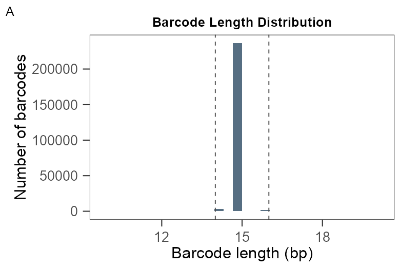

Panel A: barcode length, C1_p01

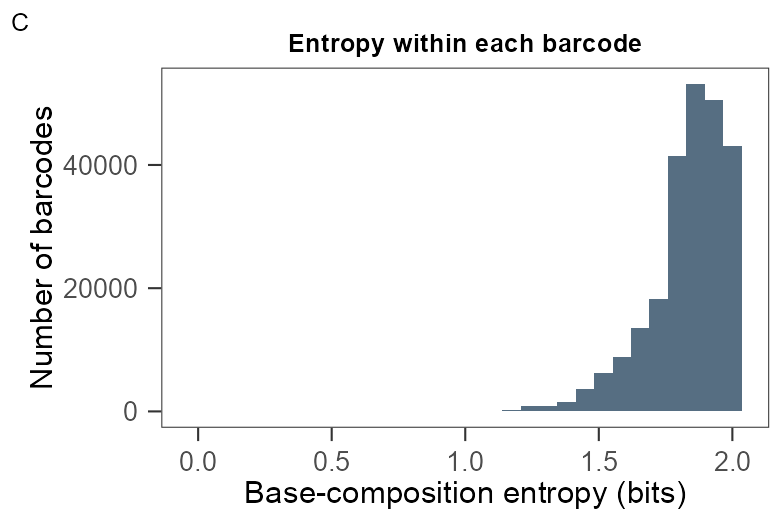

Panel C: base-composition entropy, C1_p01

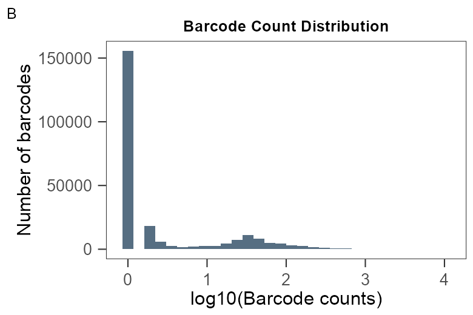

Panel B: barcode abundance, C1_p01

D · Length summary

| Length group | Sequences | Reads | Of sequences | Of reads |
| --- | --- | --- | --- | --- |
| 14 - 16 bp | 241,529 | 4,902,605 | 99.6% | 99.7% |
| < 14 bp | 762 | 12,585 | 0.3% | 0.3% |
| > 16 bp | 103 | 254 | 0.0% | 0.0% |

Sequence share = group sequences / all extracted sequences. Read share = group reads / all extracted reads. Rounded shares may not sum to exactly 100%.

**No drug r3 · passage 30**

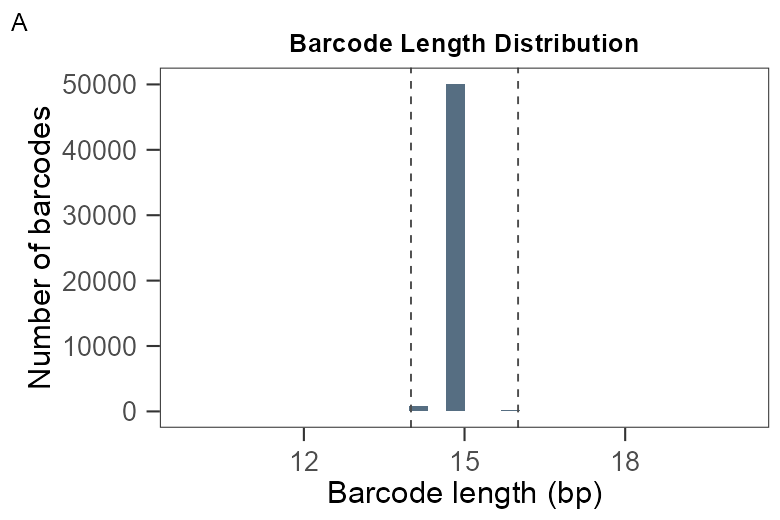

Panel A: barcode length, C1_p30

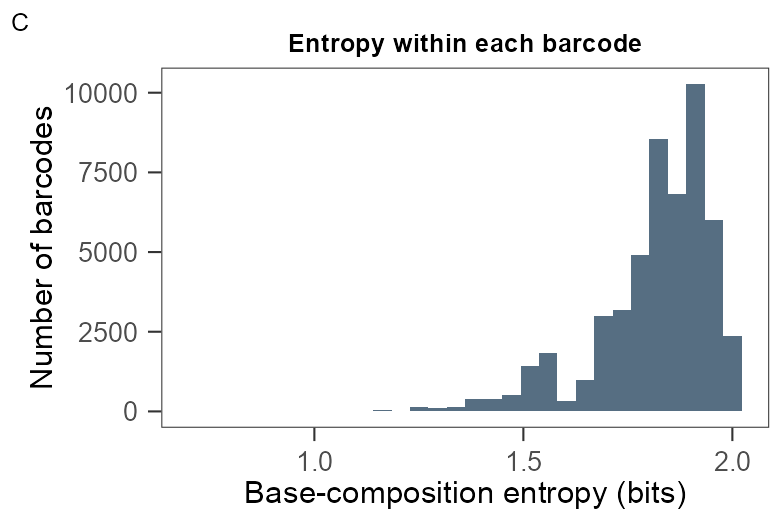

Panel C: base-composition entropy, C1_p30

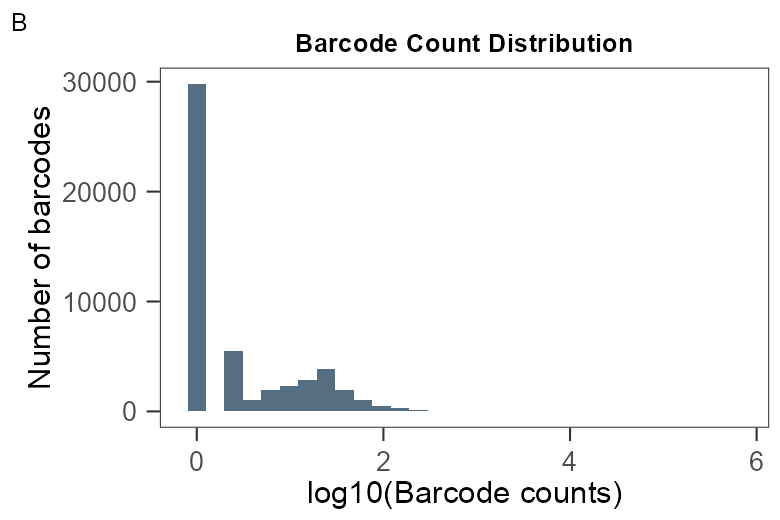

Panel B: barcode abundance, C1_p30

D · Length summary

| Length group | Sequences | Reads | Of sequences | Of reads |
| --- | --- | --- | --- | --- |
| 14 - 16 bp | 51,227 | 4,237,400 | 99.5% | 99.8% |
| < 14 bp | 225 | 8,402 | 0.4% | 0.2% |
| > 16 bp | 42 | 114 | 0.1% | 0.0% |

Sequence share = group sequences / all extracted sequences. Read share = group reads / all extracted reads. Rounded shares may not sum to exactly 100%.

**Three different uses of “entropy”.** Panel C measures base composition within one barcode, in bits. The paper’s Extended Data Figure 1 instead measures nucleotide variation across the barcode library at each sequence position, using natural logarithms. The population diversity plots below use abundances of whole lineages. These measurements answer different questions and must not be compared as though they were the same score.

## Following the mixture over time

The following plots show the same four barcode identities in every panel, chosen from the authors’ dominant-barcode table using summed published mean frequencies across the six selected populations. Their colours stay fixed. A barcode label is its DNA identifier, not a treatment name or an inferred mutation.

Read the **thickness of a coloured band** as that group’s fraction of all reads. **All remaining barcodes** adds together every extracted lineage other than the four displayed separately. **No extracted barcode** represents input reads without an accepted extracted barcode. These groups are kept separate, and every vertical slice adds to 100%. Neither group is automatically classified as sequencing errors. This is our explicit read-accounting denominator. The denominator used for the publication’s final-frequency table is examined separately below.

**Chloramphenicol · replicate 1**

[interactive chart not shown]

**Chloramphenicol · replicate 2**

[interactive chart not shown]

**Chloramphenicol · replicate 3**

[interactive chart not shown]

**No antibiotic · replicate 1**

[interactive chart not shown]

**No antibiotic · replicate 2**

[interactive chart not shown]

**No antibiotic · replicate 3**

[interactive chart not shown]

Hover to identify a band. The areas interpolate between measured passages; they do not imply observations at every intervening generation. A rise means an increasing share of measured reads. Inferring resistance or assigning a causal mutation would require additional evidence.

## Diversity asks how many lineages contribute

All diversity calculations use the **complete lineage counts**, before any display grouping into “All remaining barcodes”. The three panels answer different questions: how many lineages are detected; how many equally abundant lineages would give the observed Shannon diversity; and how strongly one lineage dominates. For example, four equally abundant lineages give a value of four for all three. In the bottom panel, a value of 2 means the largest lineage accounts for half the extracted barcode reads; a value near 1 means one lineage dominates.

For this constant-concentration experiment, the authors reported faster loss of lineage diversity under low chloramphenicol than in the other conditions (Extended Data Figure 6). The comparison here focuses on chloramphenicol and the untreated control. It can check that contrast, while all three replicates remain visible. [Study, constant-drug results](https://doi.org/10.1038/s41559-020-1103-z)

[interactive chart not shown]

At passage 30, the median Shannon effective number is **19.5 lineages with chloramphenicol** and **97.5 without antibiotic**. Across **11 of 12** matched sampled passages, the chloramphenicol populations have the lower median. This describes the contrast in the reconstructed observations. It is not a formal test of the rate of diversity loss or a replication of all the authors’ diversity calculations.

Replicates differ substantially: at passage 30, the chloramphenicol values range from **11.2 to 130.2**, and the untreated values range from **46.3 to 113.8**. The median contrast does not mean that every treated population has lower diversity than every untreated population.

For the effective-number panels, frequencies are normalized **among extracted barcode reads**, so they describe the observed lineage mixture. The exported data also contain calculations using all input reads as an alternative denominator. Sequencing depth and extraction yield affect detection of rare lineages, so a lower richness value alone is not proof of biological extinction. The shared initial sample does not provide six independent baseline observations. Because clustering is performed separately for each pooled population, its assignments of the shared initial reads can differ. Differences between passage-zero diversity values therefore do not represent different starting biological populations.

Cluster summaries at matched early and final passages

Calculated with barbac::cluster_stats() after reconstructing each sample

| Population | Passage | Detected lineages | One-read lineages | Largest lineage | Top 10 lineages |
| --- | --- | --- | --- | --- | --- |
| Low CMP r1 | 2 | 119,502 | 10,369 | 0.36% | 2.56% |
| Low CMP r1 | 30 | 6,505 | 2,030 | 48.03% | 86.80% |
| Low CMP r2 | 2 | 118,036 | 10,146 | 0.36% | 2.48% |
| Low CMP r2 | 30 | 59,970 | 6,564 | 40.41% | 62.81% |
| Low CMP r3 | 2 | 117,320 | 10,479 | 1.08% | 3.53% |
| Low CMP r3 | 30 | 7,995 | 3,222 | 35.05% | 83.20% |
| No drug r1 | 2 | 107,298 | 9,815 | 0.58% | 3.66% |
| No drug r1 | 30 | 16,040 | 3,913 | 9.01% | 41.13% |
| No drug r2 | 2 | 111,988 | 8,990 | 0.41% | 2.85% |
| No drug r2 | 30 | 12,034 | 2,338 | 32.19% | 62.65% |
| No drug r3 | 2 | 115,763 | 9,954 | 5.01% | 7.41% |
| No drug r3 | 30 | 16,339 | 3,355 | 13.41% | 48.71% |

The last two columns are shares of extracted barcode reads. One-read lineages are detected clusters supported by one read in this sample. Their count is not a false-positive count.

The last two columns show concentration of the observed population: a larger share held by one or ten lineages means fewer lineages dominate the read counts. Passages 2 and 30 are available in every selected population. Rare lineages can be missed at finite sequencing depth, so absence of reads is not proof of absence of cells.

## What agrees with the published measurements?

The strongest available numerical checks are the sample statistics in Supplementary Table 1c and the 20 dominant-barcode entries per population in Supplementary Table 4b. We use the **same treatment, replicate and passage** for each comparison. The comparison includes all 120 selected population/barcode entries, including the shorter barcode reported for one untreated replicate.

There is a source discrepancy to resolve before calling the final frequencies an exact reproduction. For **Low CMP r1 at passage 30**, Table 4b’s 20 final frequencies sum to **86.94%**, while Table 1c reports barcode extraction from **80.24%** of input reads. If both use all input reads, the subset of 20 lineages cannot exceed the total fraction with identified barcodes. The difference is far larger than rounding. Different denominators or a mismatch between the published tables could explain it; the supplied material does not resolve which.

Can the published final frequencies use all input reads?

A consistency check between Supplementary Tables 4b and 1c

| Population | Top-20 frequencies summed | All reads with identified barcodes | All-input interpretation |
| --- | --- | --- | --- |
| Low CMP r1 | 86.94% | 80.24% | Cannot reconcile |
| Low CMP r2 | 61.16% | 77.16% | Not ruled out |
| Low CMP r3 | 83.96% | 88.43% | Not ruled out |
| No drug r1 | 51.36% | 92.61% | Not ruled out |
| No drug r2 | 67.23% | 81.51% | Not ruled out |
| No drug r3 | 56.34% | 80.30% | Not ruled out |

Not ruled out does not establish the denominator. The check allows for rounding of the extraction fraction.

[interactive chart not shown]

Solid and dashed lines compare the number of detected lineages. Differences can come from extraction rules and clustering, including different treatment of rare sequences. Fewer clusters do not by themselves establish better correction.

[interactive chart not shown]

Each barcode has two points at the last sampled passage, corresponding to the two barbac denominators. Published values are plotted as provided; their denominator remains unresolved. The dashed line indicates equal numeric frequencies. A barcode absent under its exact published identifier is assigned zero in both versions and retained in every calculation. For example, a published frequency of 10% and a barbac frequency of 9% differ by **one percentage point**.

Final-frequency comparison with both denominators

Twenty published barcode entries per population

| Population | Barcodes | Spearman | Mean absolute difference: all input (pp) | Mean absolute difference: extracted (pp) |
| --- | --- | --- | --- | --- |
| Low CMP r1 | 20 | 0.9985 | 0.833 | 0.073 |
| Low CMP r2 | 20 | 1.0000 | 0.682 | 0.054 |
| Low CMP r3 | 20 | 1.0000 | 0.450 | 0.078 |
| No drug r1 | 20 | 0.9940 | 0.179 | 0.090 |
| No drug r2 | 20 | 0.9985 | 0.604 | 0.055 |
| No drug r3 | 20 | 0.9955 | 0.537 | 0.048 |

pp = percentage points. Spearman measures rank agreement and is unchanged by positive rescaling within a population. It is not an accuracy percentage. The source discrepancy prevents attributing all absolute differences to clustering.

The selected barcodes were defined by the publication, not chosen because barbac agreed with them. They are abundant lineages, so these checks do not establish accuracy for the much larger set of rare lineages. Author mean frequencies are also retained in the exported table; we do not claim exact agreement of means without resolving the denominator, initial-timepoint and averaging conventions.

## Inspect the observations behind the plots

Search by population, barcode or passage. Both barbac denominators are available. “Published final” is populated only at the final passage because a full published per-timepoint count matrix was not available in the supplementary tables. Blank reference entries mean unavailable reference measurements, not zero abundance.

| Population | Barcode | Passage | Barbac / input reads (%) | Barbac / extracted reads (%) | Published final (%) |
| --- | --- | --- | --- | --- | --- |
| No drug r1 | AACGTATATACGTTG | 0 | 0.003795108255462987 | 0.004803902971793114 |  |
| No drug r1 | AACGTATATACGTTG | 1 | 0.004500964692408595 | 0.005813411735581557 |  |
| No drug r1 | AACGTATATACGTTG | 2 | 0.008049568688843229 | 0.008564918389618138 |  |
| No drug r1 | AACGTATATACGTTG | 4 | 0.005118664964114306 | 0.005404282458018749 |  |
| No drug r1 | AACGTATATACGTTG | 6 | 0.03601485718212755 | 0.03855313652842018 |  |
| No drug r1 | AACGTATATACGTTG | 8 | 0.03786859538263347 | 0.04464098977045097 |  |
| No drug r1 | AACGTATATACGTTG | 10 | 0.1033978979742869 | 0.1179402094824868 |  |
| No drug r1 | AACGTATATACGTTG | 12 | 0.2475603077014752 | 0.3206821807392383 |  |
| No drug r1 | AACGTATATACGTTG | 14 | 0.6636825796622382 | 0.752644440361341 |  |
| No drug r1 | AACGTATATACGTTG | 16 | 2.124410852252202 | 2.246861953328696 |  |

[output cut: 1610 more lines]

The complete reconstructed count matrices, including explicit zero counts, are saved separately as one compressed CSV per population in the accompanying results folder. The explorer above covers the publication’s dominant barcode entries.

Complete count matrices: chloramphenicol replicate 1, replicate 2, replicate 3; no antibiotic replicate 1, replicate 2, replicate 3. These links require the accompanying results folder. The filtered explorer CSV is embedded in the report and can also be downloaded offline.

## Processing time and interpretation limits

Barbac LV clustering time

One pooled trajectory reconstruction per population

| Population | Input sequences | Pooled clusters | Elapsed (s) | CPU time (s) | Pooled read observations |
| --- | --- | --- | --- | --- | --- |
| Low CMP r1 | 1,185,394 | 203,034 | 1,238.24 | 1,220.24 | 54,143,804 |
| Low CMP r2 | 1,306,601 | 203,437 | 1,359.41 | 1,340.82 | 63,262,684 |
| Low CMP r3 | 1,261,673 | 192,267 | 1,268.78 | 1,250.75 | 62,288,463 |
| No drug r1 | 1,504,230 | 212,722 | 1,366.68 | 1,345.77 | 59,526,355 |
| No drug r2 | 1,533,301 | 218,384 | 1,517.87 | 1,497.02 | 64,377,654 |
| No drug r3 | 1,566,596 | 218,983 | 1,436.53 | 1,416.29 | 64,926,649 |

Times cover the optimized release clustering call, including support ordering, with up to 3 concurrent release-clustering processes. Recorded R platform: aarch64-apple-darwin20. Elapsed time includes scheduling; CPU time reports active process computation. Download, quality checks, mapping, extraction and report generation are excluded. Each population includes the shared baseline once; pooled read totals must not be summed as unique sequencing input.

The release package was compiled with optimization enabled. Its complete compiler command and binary hash are saved with the timing validation.

6 complete release reruns were compared with existing clustering results. Every barcode assignment and centroid count matched exactly.

The result notes record the hardware and concurrent work for the checked-in local measurements, including the earlier unoptimized development timings archived separately from the release table.

Clustering uses barbac LV at distance 3, support ordering, merge ratio 20 and the Poisson indel option, with an assumed error rate of 0.005. These settings were fixed before evaluating publication agreement. Each population is pooled over its timepoints with the shared initial population, so reconstruction uses future samples retrospectively. It is not a prospective prediction.

Distance 3 allows candidate barcodes to differ by up to three insertions, deletions or substitutions. The assumed 0.005 error rate (0.5% per base) is a separate parameter used when scoring possible parents; it is not estimated from the publication-agreement percentage. Abundance guards also constrain merging, so being within three edits does not automatically put two barcodes together.

This analysis uses build **barbac-2026-09-10-eligible-parent-v14**. An exact search optimization skips wider-search parents that cannot satisfy the existing abundance guard, after all distance-one candidates have been examined. The old and new builds give identical assignments on a 12,000-sequence real-data check, and indexed search agrees with exhaustive scans in the regression tests. The scoring and merge rules are unchanged. These application timings are not a replacement for the separate controlled method benchmark.

This report tests whether barbac reconstructs the selected study measurements. It does not establish the correctness of every barcode assignment, identify causal mutations, or reproduce the paper’s entire analysis. Complete author count tables and alignment code would allow a more exact reconciliation of extraction, individual trajectories and diversity. The published methods state that their custom analysis scripts are available on request; no request has been sent. False-positive and false-negative counts require known true labels; the publication’s processed output is not such a truth set.

## Sources and reproducibility

- [Study and Methods](https://doi.org/10.1038/s41559-020-1103-z): experimental design, barcode construct, processing conventions and biological interpretation.
- [BioProject PRJNA592529](https://www.ncbi.nlm.nih.gov/bioproject/PRJNA592529): raw reads from the constant-concentration experiment. The accompanying sample manifests record every selected run and its checksum.
- [Author supplementary tables](https://media.springernature.com/original/springer-static/esm/art%3A10.1038%2Fs41559-020-1103-z/MediaObjects/41559_2020_1103_MOESM3_ESM.xlsx): Table 1c supplies sample totals and processing summaries; Table 4b supplies dominant barcode identities and mean/final frequencies.

The accompanying analysis folder contains the R scripts, cassette FASTA, checksum receipts, complete reconstructed count matrices and a SLURM script. The report embeds its figures and interactive tables for offline viewing. The SLURM script is prepared for reuse and has not been submitted to a cluster.